# Design HW2

Charles

2018/03/20

# 1.Exercise 2.4

Using randomizationmethods, test the null hypothesis that the two treatments have equal average numbers of Copepoda versus a two-sided alternative.

```r
#Permutation test
#兩試驗樣本數相同下進行
#原本資料計算
library(dplyr)
library(knitr)
A<-c(256,159,149);A
```

```
## [1] 256 159 149
```

```r
B<-c(54,123,247);B
```

```
## [1]  54 123 247
```

```r
D<-A[]-B[];D<-matrix(D,ncol = length(A))
#A與B資料的差異和
D_sum<-apply(D,1,sum)
#各種排列數差異和計算
W<-c(A,B)
W<-matrix(data = W,ncol =length(W) )
W_sum<-apply(W,1,sum)
cb_W<- combn(W,3)
cb_A_sum<-apply(cb_W,2,sum)
cb_B_sum=NULL
n=NULL
for(i in 1:choose(length(W),length(W)/2)){
  n=W_sum-cb_A_sum[i]
  cb_B_sum=c(cb_B_sum,n)
}
all_d_sum<-cb_A_sum-cb_B_sum
#將所有排列差異和按照順序列出
all_d_sum <- matrix(sort(all_d_sum),ncol = 5,byrow = T)
print(all_d_sum)
```

```
##      [,1] [,2] [,3] [,4] [,5]
## [1,] -336 -316 -264 -140 -126
## [2,] -122  -88  -70  -68  -50
## [3,]   50   68   70   88  122
## [4,]  126  140  264  316  336
```

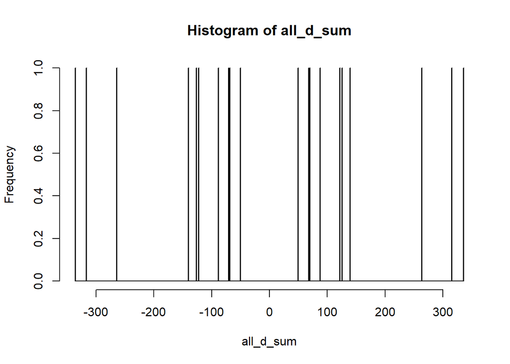

```r
#畫直方圖
hist(all_d_sum,breaks = 2000)
```

```r
#計算P值(計算有幾種可能使得兩者的差異絕對值不小於觀察差異)
p_value<-2*sum(1*(D_sum<=all_d_sum)/choose(length(W),length(W)/2))
p_value
```

```
## [1] 0.4
```

```r
#統計模擬看看
W
```

```
##      [,1] [,2] [,3] [,4] [,5] [,6]
## [1,]  256  159  149   54  123  247
```

```r
s_d=NULL
P_hat_value=NULL
sd_p_hat=NULL
for (j in 1:1000) {
  s_d=NULL
  for(i in 1:1000){
   x <- sample(W,3)
   sx <- sum(x)
   sy <- sum(W)-sum(x)
   sd <- sx-sy
   s_d=c(s_d,sd)
}
p_hat_value <- 2*sum(1*(D_sum<=s_d[-1]))/1000
P_hat_value = c(P_hat_value,p_hat_value)
}
sort(P_hat_value)
```

[output not shown]

[output cut: 76 more lines]

```r
P_hat_value <- sum(P_hat_value)/1000
sd_p_hat <- (p_hat_value*(1-p_hat_value))/1000
print(paste('P hat value :' , P_hat_value))
```

```
## [1] "P hat value : 0.39906"
```

```r
print(paste('stand error of p hat :' ,sd_p_hat))
```

```
## [1] "stand error of p hat : 0.000234624"
```

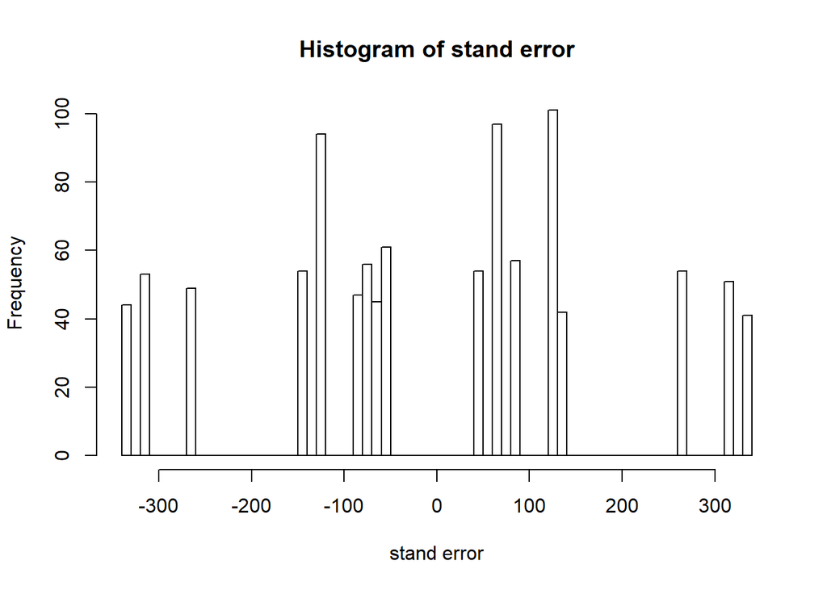

```r
hist(s_d,breaks = 50,main="Histogram of stand error",xlab = "stand error")
```

# 2.

$E\left(\widehat\sigma ^{2}\right)=\sigma^{2}$

We know

$Y_{ij}\sim N(u_i,\sigma^{2})$ , $E(Y_{ij}^2)=u_i^2+\sigma^2$

$Y_{i.}\sim N(u_{i,}\frac{\sigma^{2}}{n})$ , $E(Y_{i.}^2)=u_i^2+\frac{\sigma^2}{n_i}$

One remaining parameter to estimate is

$Var({\epsilon}_{ij})={\sigma}^2 , j=1,2,...,n_i , i=1,2,...,g$

Consider

$\hat{{\sigma}^2}=MS_E=\frac{SS_E}{N-g}=\frac{\sum_{i=1}^{g}\sum_{j=1}^{n_i}(Y_{ij}-\bar{Y}_{i.})^2}{N-g}$

In both the separate means and single means models,$\hat{\sigma}^2$is unbiased for $\sigma^2$,i.e.

$E(\hat{{\sigma}^2})=E(\frac{\sum_{i=1}^{g}\sum_{j=1}^{n_i}(Y_{ij}-\bar{Y}_{i.})^2}{N-g})$

$=E(\frac{\sum_{i=1}^{g}\sum_{j=1}^{n_i}(Y_{ij}^2-2Y_{ij}\bar{Y}_{i.}+\bar{Y}_{i.}^2))}{N-g}$

$=E(\frac{\sum_{i=1}^{g}\sum_{j=1}^{n_i}(Y_{ij}^2-2Y_{ij}\bar{Y}_{i.}+\bar{Y}_{i.}^2))}{N-g}$

$=E(\frac{\sum_{i=1}^{g}(\sum_{j=1}^{n_i}Y_{ij}-n_i\bar{Y}_{i.}^2)}{N-g})$

$=\frac{\sum_{i=1}^{g}n_i(u_i^2+\sigma^2-\sum_{i=1}^{g}n_i(u_i^2+\frac{\sigma^2}{n_i}))}{N-g}$

$=\frac{\sum_{i=1}^{g}n_i\sigma^2-\sum_{i=1}^{g}\sigma^2}{N-g}$

$=\sigma^2$